# Descriptive Statistics

Julian Frattini

2026-01-26

This notebook contains the visualization of descriptive statistics of the NaPiRE 2024 run. These statistics serve to provide an overview of the status quo of requirements engineering in 2024. As such, they update the status quo previously published by Wagner et al.[^1]

```r
get_mode <- function(x) {
  ux <- unique(x)
  tab <- tabulate(match(x, ux))
  modes <- ux[tab == max(tab)]
  paste(sort(modes), collapse = ", ")
}
```

## Data Loading

First, we load the data set with all its variables and retain only relevant columns.

```r
d <- load_data_2024(data_path = "../data", file = "data_preprocessed.csv") %>%
  #select_if(c(negate(is.character)) %>%
  select(lfdn, duration,
         # meta-data
         v_3, v_23, Country, ISO, v_1, v_457, v_16, v_357, v_377, v_17,
         # communication
         v_25, v_359, v_452, v_380, v_368,
         # elicitation
         v_28, v_29, v_572, v_34, v_36, v_37, v_38, v_39, v_40, v_41, v_42, v_43,
         v_44, v_47, v_667, v_668, v_669, v_461, v_454, v_45,
         # assumption
         v_455,
         # benefit
         v_482, v_484, v_487,
         # documentation
         v_76, v_73, v_79, v_68, v_70, v_71, v_74, v_78, v_77, v_75, v_69, v_72,
         v_466, v_557, v_576, v_80,
         v_87, v_92, v_88, v_91, v_83, v_93, v_89, v_90, v_84, v_86, v_82, v_85,
         v_463, v_558, v_575, v_95,
         v_577,
         v_670, v_671, v_672, v_673, v_674, v_675, v_676, v_677,
         # non-functional requirements
         v_97, v_98, v_99, v_100, v_101, v_102, v_303, v_103, v_422, v_104,
         # reasons to stop requirements analysis
         v_559, v_560, v_561, v_562, v_563, v_564, v_565, v_566, v_567, v_568, v_569,
         # requirements validation
         v_158, v_159, v_160, v_161, v_162, v_573, v_574, v_163,
         # problems
         v_385, v_386, v_418, v_409, v_410, v_388, v_389, v_392, v_393, v_394,
         v_395, v_396, v_397, v_399, v_401, v_402, v_403, v_404, v_411, v_405,
         v_408, v_407, v_406, v_387, v_417, v_459, v_571,
         # top problems
         v_661, v_662, v_663, v_664, v_665
         )

#str(d)
```

## Data Visualization

```r
get_resp_distribution <- function(vars) {
  d.responses <- d %>%
    select(all_of(vars)) %>%
    drop_na() %>%
    rowwise() %>%
    mutate(count = sum(c_across(all_of(vars)))) %>%
    ungroup() %>%
    select(count)

  p <- ggplot(d.responses, aes(count)) +
    geom_bar(stat = "count") +
    geom_text(aes(label = after_stat(count)), stat = "count",
              vjust = -0.8, colour = "black", size = 3) +
    labs(x = "Number of selected options", y = "Frequency") +
    scale_x_continuous(breaks = seq(0, max(d.responses$count))) +
    theme_bw()

  print(p)

  d.responses %>%
    summarize(
      median = median(count),
      mode   = get_mode(count),
      iqr    = IQR(count),
      q1     = quantile(count, 0.25),
      q3     = quantile(count, 0.75),
      mad    = mad(count, constant = 1),
      mean   = mean(count),
      sd     = sd(count)
    ) %>%
    t()
}
```

### Meta-Data

First, we visualize the demographic meta-data about participants. The first plot visualizes the answers to the question “In which country are you personally located?” (`v_23`). This plot shows the distribution of responses from all participants that completed at least the first two, real sections of the questionnaire ($n = 346$).

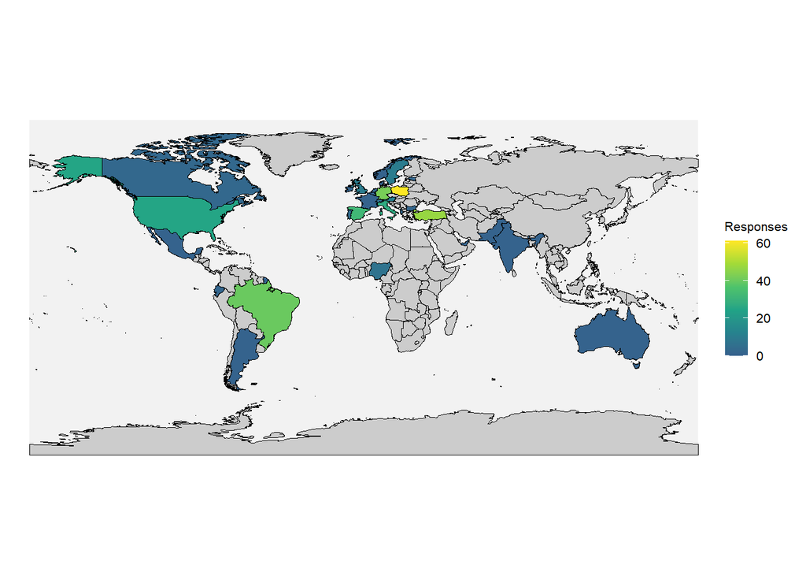

```r
country.summary <- d %>%
  filter(!(is.na(Country)) & !(is.na(v_28))) %>%
  group_by(ISO) %>%
  tally() %>%
  rename(Responses = "n")

worldplot(data = data.frame(country.summary),
          ColName = "Responses",
          CountryName = "ISO",
          CountryNameType = "isoa2",
          rangeVal = c(0, max(country.summary$Responses)),
          # annote = TRUE, # show country ISO code
            )
```

```r
# uncomment to save the figure as a file
ggsave(filename = "../figures/descriptive/participation.pdf", device = "pdf",
       width = 10, height = 6, units = "in")
```

Alternatively, this second plot shows all the distribution of all fully completed responses ($n = 268$).

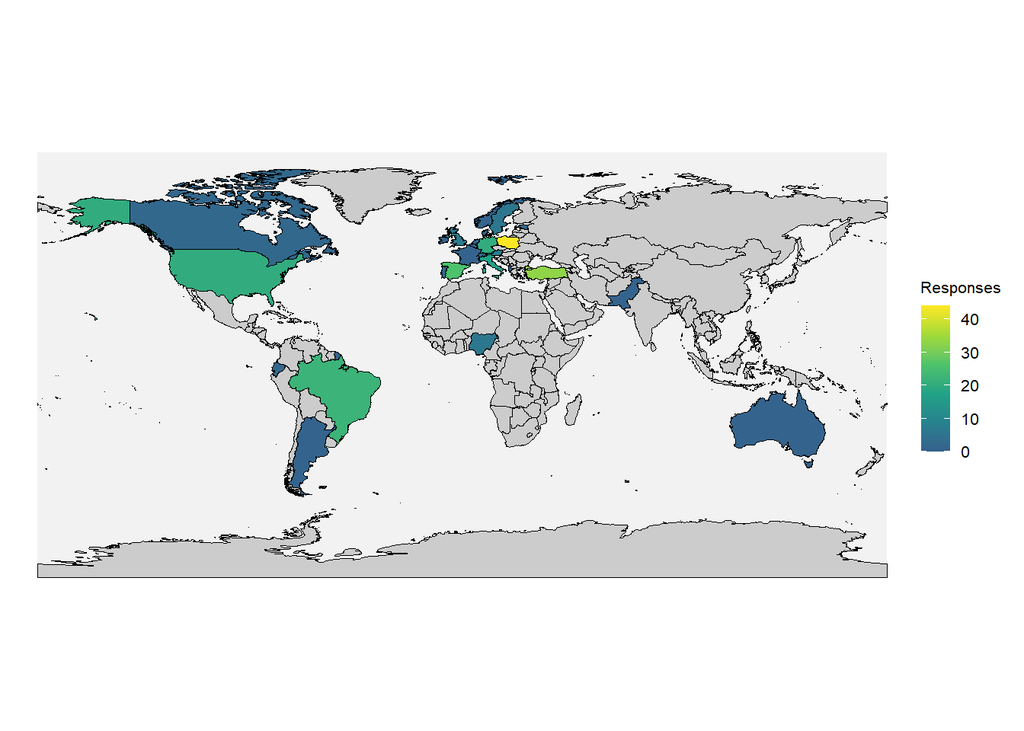

```r
country.summary <- d %>%
  drop_na() %>%
  group_by(ISO) %>%
  tally() %>%
  rename(Responses = "n")

worldplot(data = data.frame(country.summary),
          ColName = "Responses",
          CountryName = "ISO",
          CountryNameType = "isoa2",
          rangeVal = c(0, max(country.summary$Responses)),
          # annote = TRUE, # show country ISO code
            )
```

In the following, we will visualize only the distribution of responses that completed at least the first two real sections (i.e., filtering by `v_28`).

Answers to the question “How many people are involved in your project?” (`v_3`)

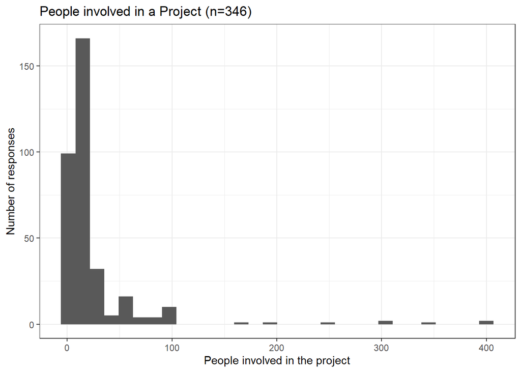

```r
d %>%
  filter(!(is.na(v_28)) & v_3 >= 0) %>%
  ggplot(aes(x = v_3)) +
    geom_histogram(bins = 30) +
    labs(x = "People involved in the project", y = "Number of responses") +
    theme_bw() +
    ggtitle(paste0("People involved in a Project (n=", nrow(drop_na(select(d, v_28))), ")"))
```

Answers to the question “How many people are involved in your project?” (`v_3`) stratified by answers to the question “How would you personally characterise the way your project works?” (`v_457`), both on an absolute and a logarithmic scale.

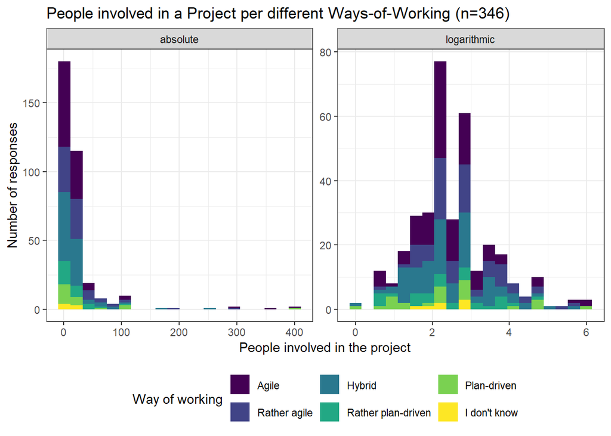

```r
d %>%
  filter(!(is.na(v_28)) & v_3 >= 0) %>%
  select(lfdn, v_3, v_457) %>%
  mutate(v_3l = log(v_3)) %>%
  pivot_longer(cols = c(v_3, v_3l), names_to = "variable", values_to = "value") %>%
  mutate(variable = factor(variable,
                           levels = c("v_3", "v_3l"),
                           labels = c("absolute", "logarithmic"),
                           ordered = TRUE)) %>%
  ggplot(aes(x = value, fill = v_457)) +
    geom_histogram(bins = 20) +
    labs(x = "People involved in the project", y = "Number of responses", fill = "Way of working") +
    facet_wrap(~variable, scales = "free") +
    theme_bw() +
    theme(legend.position = "bottom") +
    ggtitle(paste0("People involved in a Project per different Ways-of-Working (n=", nrow(drop_na(select(d, v_28))), ")"))
```

Answers to the question “Please select the main industrial sector of your project or the application domain of the software you build.” (v_1)

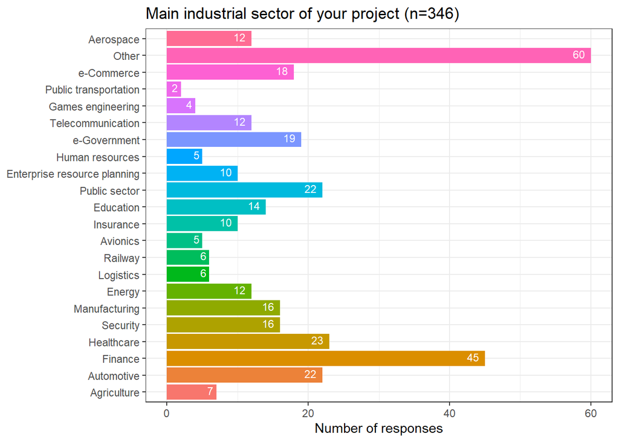

```r
d %>%
  filter(!(is.na(v_28))) %>%
  ggplot(aes(y = v_1, fill = v_1)) +
    geom_bar() +
    labs(x = "Number of responses") +
    theme_bw() +
    theme(axis.title.y = element_blank()) +
    guides(fill = "none") +
    geom_text(aes(label = after_stat(count)), stat = "count", hjust = 1.5, vjust = 0.3, colour = "white",
              size = 3) +
    ggtitle(paste0("Main industrial sector of your project (n=", nrow(drop_na(select(d, v_28))), ")"))
```

Answers to the question “Does your project involve external partners?” (`v_16`).

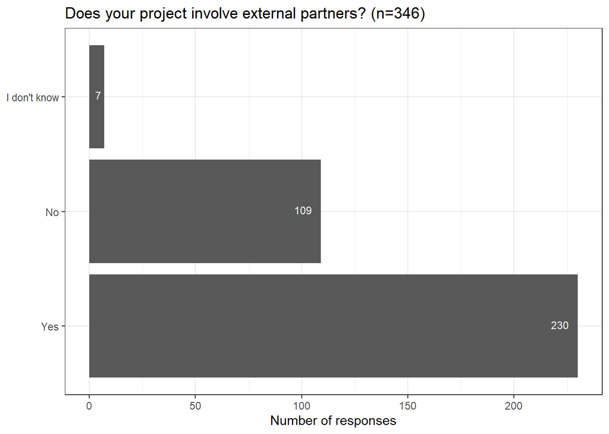

```r
d %>%
  filter(!(is.na(v_28))) %>%
  ggplot(aes(y = v_16)) +
    geom_bar() +
    geom_text(aes(label = after_stat(count)), stat = "count", hjust = 1.5, vjust = 0.3, colour = "white",
              size = 3) +
    labs(x = "Number of responses") +
    theme_bw() +
    theme(axis.title.y = element_blank()) +
    ggtitle(paste0("Does your project involve external partners? (n=", nrow(drop_na(select(d, v_28))), ")"))
```

Answers to the question “Is your project distributed?” (`v_357`).

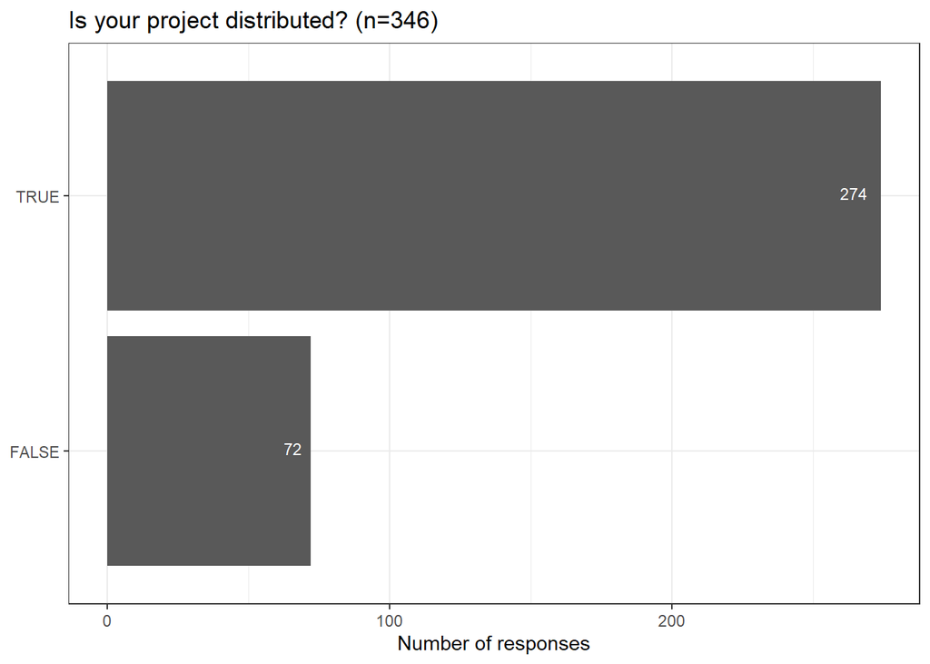

```r
d %>%
  filter(!(is.na(v_28))) %>%
  ggplot(aes(y = v_357)) +
    geom_bar() +
    geom_text(aes(label = after_stat(count)), stat = "count", hjust = 1.5, vjust = 0.3, colour = "white",
              size = 3) +
    labs(x = "Number of responses") +
    theme_bw() +
    theme(axis.title.y = element_blank()) +
    ggtitle(paste0("Is your project distributed? (n=", nrow(drop_na(select(d, v_28))), ")"))
```

Answers to the question “Do you tend to work from home, on-site, or both?” (`v_377`).

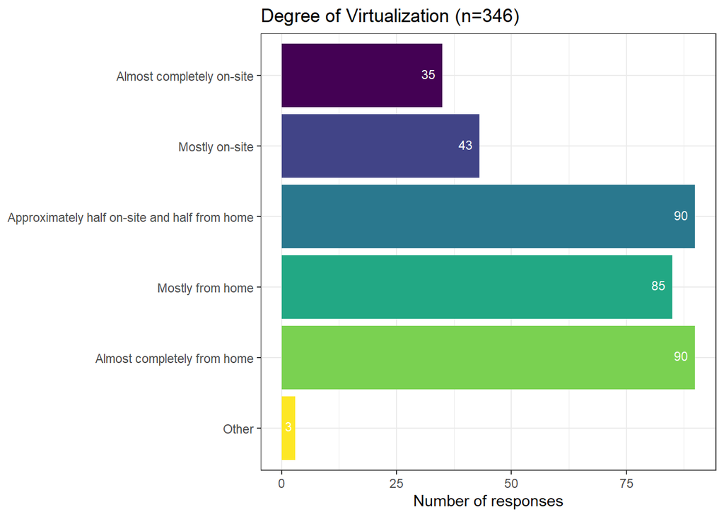

```r
d %>%
  filter(!(is.na(v_28))) %>%
  ggplot(aes(y = v_377, fill = v_377)) +
    geom_bar() +
    geom_text(aes(label = after_stat(count)), stat = "count", hjust = 1.5, vjust = 0.3, colour = "white",
              size = 3) +
    labs(x = "Number of responses") +
    theme_bw() +
    theme(axis.title.y = element_blank()) +
    guides(fill = "none") +
    scale_y_discrete(limits = rev) +
    ggtitle(paste0("Degree of Virtualization (n=", nrow(drop_na(select(d, v_28))), ")"))
```

Answers to the question “What is the main role you occupy in your project?” (`v_17`).

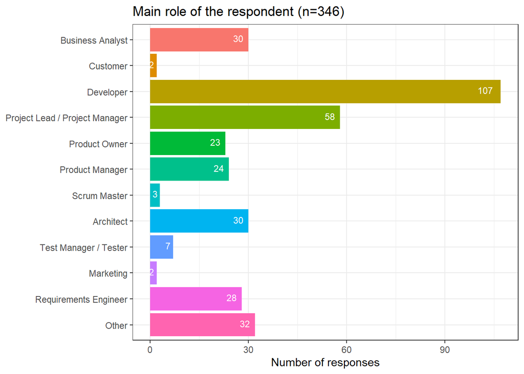

```r
d %>%
  filter(!(is.na(v_28))) %>%
  ggplot(aes(y = v_17, fill = v_17)) +
    geom_bar() +
    geom_text(aes(label = after_stat(count)), stat = "count", hjust = 1.5, vjust = 0.3, colour = "white",
              size = 3) +
    labs(x = "Number of responses") +
    theme_bw() +
    theme(axis.title.y = element_blank()) +
    guides(fill = "none") +
    scale_y_discrete(limits = rev) +
    ggtitle(paste0("Main role of the respondent (n=", nrow(drop_na(select(d, v_28))), ")"))
```

### Communication

The second section contains communication-related variables.

Answers to the three questions:

1. How would you rate the relationship between your project’s team and its customer? (`v_25`)
2. How would you rate the quality of communication inside your team? (`v_359`)
3. How would you rate the quality of communication between your team and other teams on the same project? (`v_452`)

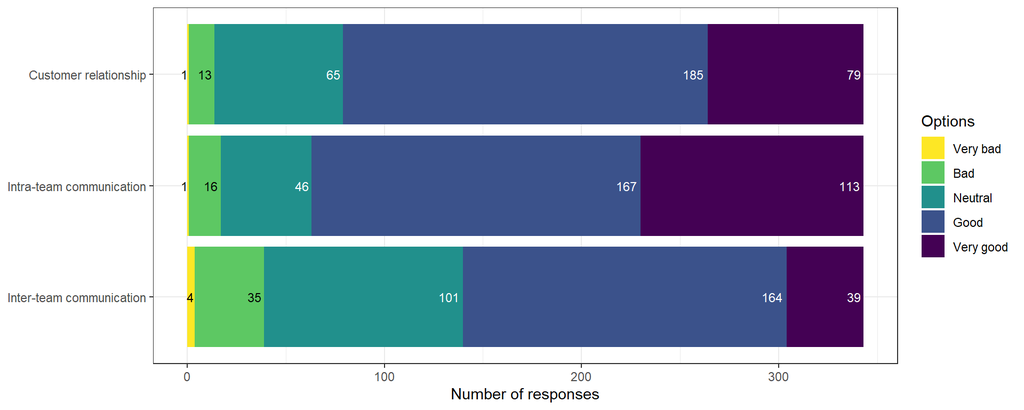

```r
d %>%
  filter(!(is.na(v_28))) %>%
  select(v_25, v_359, v_452) %>%
  drop_na() %>%
  pivot_longer(cols = c(v_25, v_359, v_452),
               names_to = "question", values_to = "answer") %>%
  mutate(question = factor(question, levels = c("v_25", "v_359", "v_452"),
                           labels = c(
                             "Customer relationship",
                             "Intra-team communication",
                             "Inter-team communication"
                           )),
         #answer = fct_rev(answer),
         textcolor = if_else(as.integer(answer) <= 3, "white", "black")
         ) %>%
  ggplot(aes(y = question, fill = answer)) +
    geom_bar(position = "stack", stat = "count") +
    geom_text(aes(label = after_stat(count), color = textcolor, group = answer),
              position = "stack", stat = "count",
              hjust = 1.2, size = 3) +
    labs(x = "Number of responses", fill = "Options") +
    theme_bw() +
    theme(legend.position = "right", axis.title.y = element_blank()) +
    #ggtitle(paste0("Rating Communication (n=", nrow(drop_na(select(d, v_28))), ")"))
    guides(fill = guide_legend(reverse = TRUE)) +
    scale_color_identity() +
    scale_y_discrete(limits = rev)
```

```r
ggsave("../figures/descriptive/communication.pdf", device = "pdf",
       width = 20, height = 5, unit = "cm")
```

Answers to the question “How often do members of your team meet, informally by chance meeting or in announced meetings?” (`v_380`)

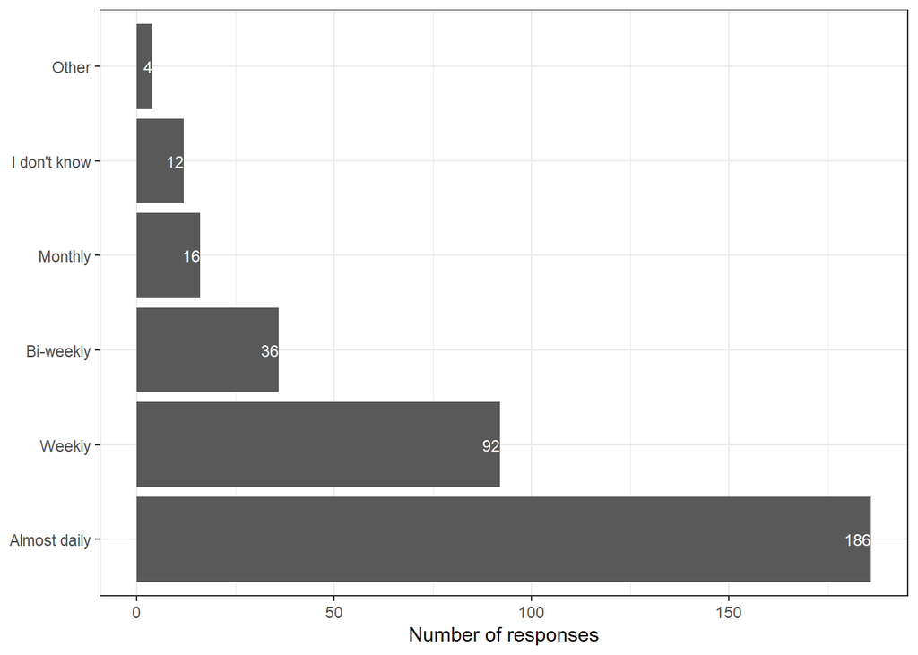

```r
d %>%
  filter(!(is.na(v_28))) %>%
  ggplot(aes(y = v_380)) +
    geom_bar() +
    geom_text(aes(label = after_stat(count)), stat = "count",
                hjust = 1, colour = "white", size = 3) +
    labs(x = "Number of responses") +
    theme_bw() +
    theme(axis.title.y = element_blank())# +
```

```r
    #ggtitle(paste0("Meeting Frequency with the Team (n=", nrow(drop_na(select(d, v_28))), ")"))

ggsave("../figures/descriptive/frequency-meeting.pdf", device = "pdf",
       width = 10, height = 4, unit = "cm")
```

Answers to the question “How often is end user feedback provided” (`v_368`)

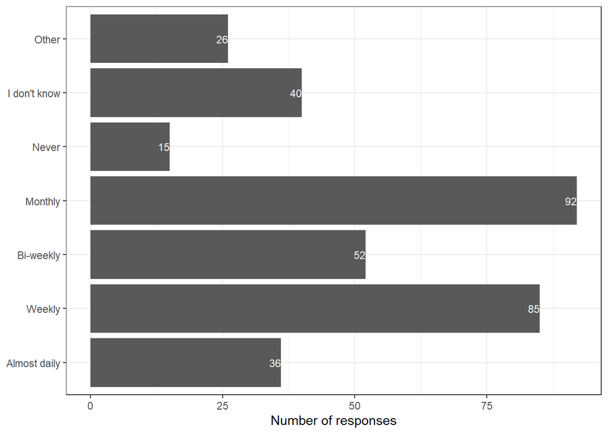

```r
d %>%
  filter(!(is.na(v_28))) %>%
  ggplot(aes(y = v_368)) +
    geom_bar() +
    geom_text(aes(label = after_stat(count)), stat = "count",
                hjust = 1, colour = "white", size = 3) +
    labs(x = "Number of responses") +
    theme_bw() +
    theme(axis.title.y = element_blank())# +
```

```r
    #ggtitle(paste0("Frequency of User Feedback (n=", nrow(drop_na(select(d, v_28))), ")"))

ggsave("../figures/descriptive/frequency-feedback.pdf", device = "pdf",
       width = 10, height = 4, unit = "cm")
```

### Requirements Elicitation

Answers to the question “How are the requirements elicited in your project?”

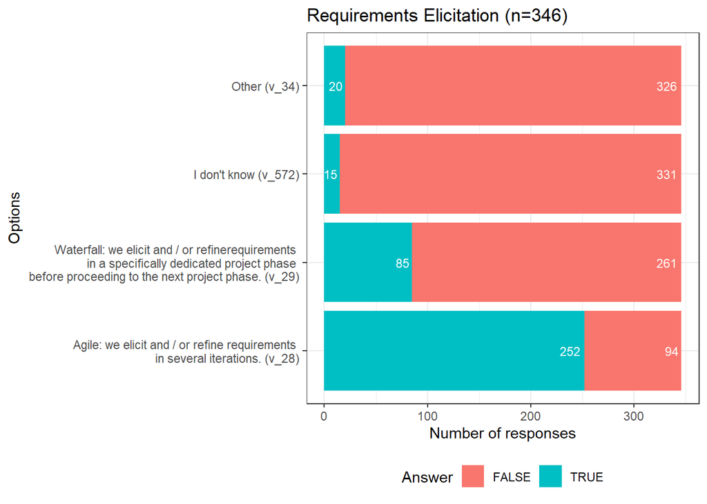

```r
d %>%
  select(v_28, v_29, v_572, v_34) %>%
  drop_na() %>%
  pivot_longer(cols = c(v_28, v_29, v_572, v_34),
               names_to = "Option", values_to = "Response") %>%
  mutate(Option = factor(Option, levels = c("v_28", "v_29", "v_572", "v_34"),
                           labels = c(
                             "Agile: we elicit and / or refine requirements \n in several iterations. (v_28)",
                             "Waterfall: we elicit and / or refinerequirements \n in a specifically dedicated project phase \n before proceeding to the next project phase. (v_29)",
                             "I don't know (v_572)",
                             "Other (v_34)"
                           ))) %>%
  ggplot(aes(y = Option, fill = Response)) +
    geom_bar(position = "stack", stat = "count") +
    geom_text(aes(label = after_stat(count)), position = "stack", stat = "count",
              hjust = 1.2, colour = "white", size = 3) +
    labs(x = "Number of responses", y = "Options", fill = "Answer") +
    theme_bw() +
    theme(legend.position = "bottom") +
    ggtitle(paste0("Requirements Elicitation (n=", nrow(drop_na(select(d, v_28))), ")"))
```

Answers to the question “Which techniques are employed to elicit requirements in your project?”

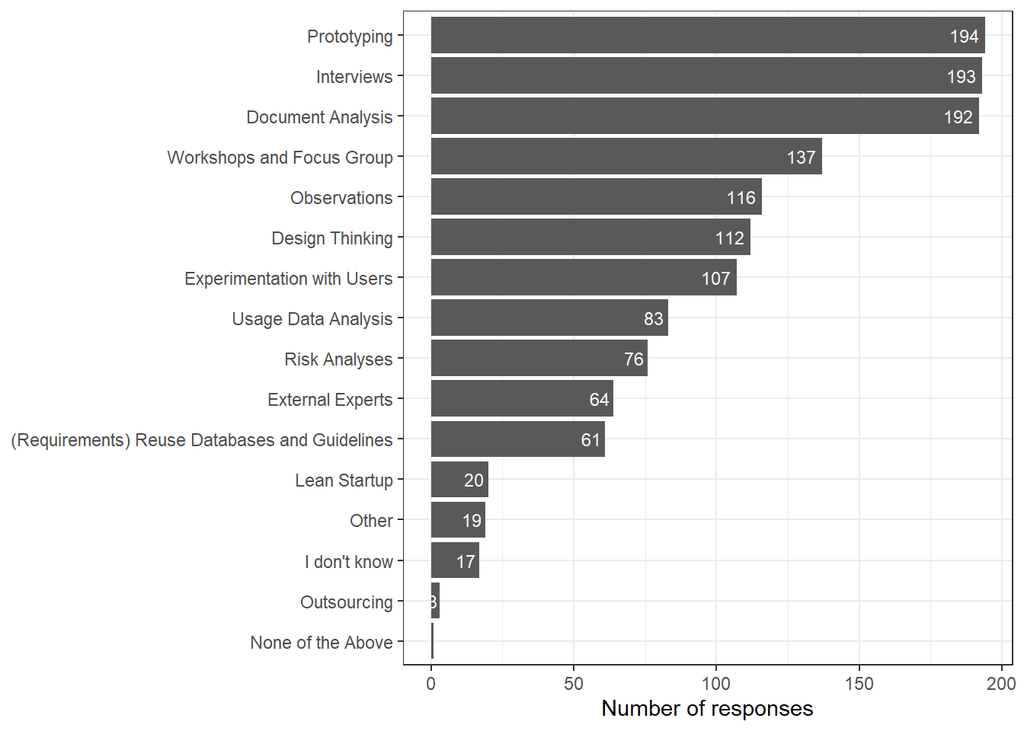

```r
d %>%
  select(v_36, v_37, v_38, v_39, v_40, v_41, v_42, v_43, v_44, v_47, v_667,
         v_668, v_669, v_461, v_454, v_45) %>%
  drop_na() %>%
  pivot_longer(cols = everything(),
               names_to = "Option", values_to = "Response") %>%
  filter(Response == TRUE) %>%
  mutate(Option = factor(Option, levels = c("v_36", "v_37", "v_38", "v_39",
                                            "v_40", "v_41", "v_42", "v_43",
                                            "v_44", "v_47", "v_667", "v_668",
                                            "v_669", "v_461", "v_454", "v_45"),
                           labels = c("Interviews", "Document Analysis", "Risk Analyses",
                                      "Prototyping", "Workshops and Focus Group",
                                      "(Requirements) Reuse Databases and Guidelines",
                                      "Design Thinking", "External Experts",
                                      "Observations", "Outsourcing",
                                      "Usage Data Analysis", "Lean Startup",
                                      "Experimentation with Users", "I don't know",
                                      "None of the Above", "Other"
                           ))) %>%
  mutate(Option = fct_rev(fct_infreq(Option))) %>%
  ggplot(aes(y = Option)) +
    geom_bar(position = "stack", stat = "count") +
    geom_text(aes(label = after_stat(count)), position = "stack", stat = "count",
              hjust = 1.2, colour = "white", size = 3) +
    labs(x = "Number of responses") +
    theme_bw() +
    theme(axis.title.y = element_blank())
```

```r
    #theme(legend.position = "bottom") +
    #ggtitle(paste0("Techniques for Requirements Elicitation (n=", nrow(drop_na(select(d, v_36))), ")"))

ggsave("../figures/descriptive/elicitation-techniques.pdf", device = "pdf",
       width = 18, height = 9, unit = "cm")
```

The following figure and table visualizes the response distribution per participant. It shows, how many options participants selected in this multiple-choice question.

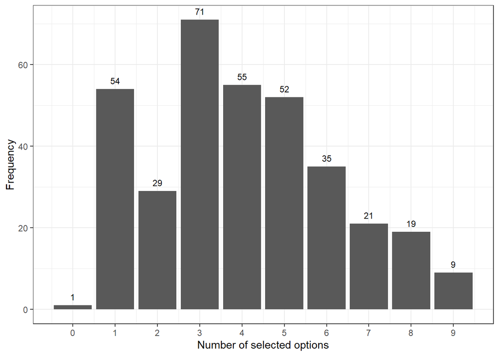

```
##        [,1]
## median "4"
## mode   "3"
## iqr    "2"
## q1     "3"
## q3     "5"
## mad    "1"
## mean   "4.031792"
## sd     "2.152619"
```

```r
get_resp_distribution(c("v_36", "v_37", "v_38", "v_39", "v_40", "v_41", "v_42",
                        "v_43", "v_44", "v_47", "v_667", "v_668", "v_669", "v_461",
                        "v_454", "v_45"))
```

### Assumptions

Answers to the question “If you are in a situation where you lack information and have to make an assumption to proceed in your project, what do you typically do?”

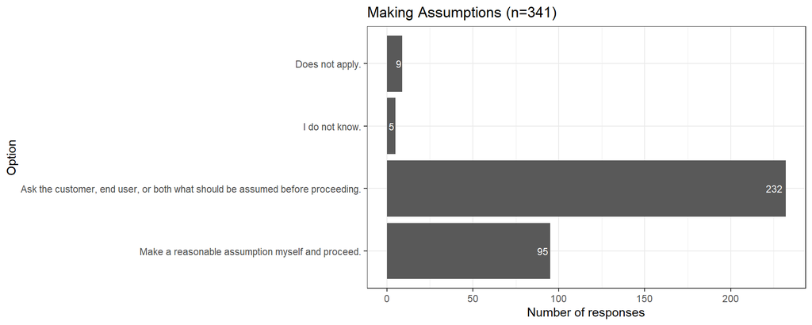

```r
d %>%
  select(v_455) %>%
  drop_na() %>%
  ggplot(aes(y = v_455)) +
    geom_bar() +
    geom_text(aes(label = after_stat(count)), position = "stack", stat = "count",
                hjust = 1.2, colour = "white", size = 3) +
    theme_bw() +
    labs(x = "Number of responses", y = "Option") +
    ggtitle(paste0("Making Assumptions (n=", nrow(drop_na(select(d, v_455))), ")"))
```

### Benefit

Answers to the question “Suppose that you know that the only people who benefit from a document that you must produce are people other than the project’s current members. Rate the following based on what best describes your behavior and thinking.”

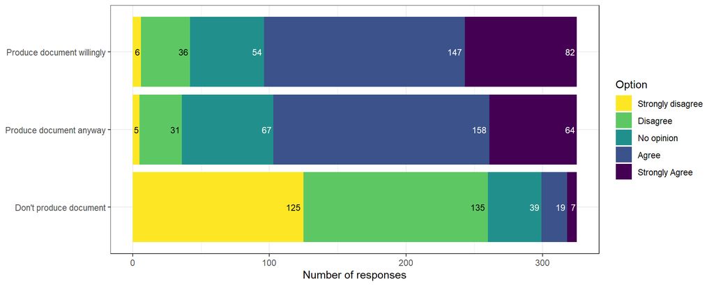

```r
d %>%
  select(v_482, v_484, v_487) %>%
  drop_na() %>%
  pivot_longer(cols = everything(),
               names_to = "question", values_to = "answer") %>%
  mutate(question = factor(question, levels = c("v_482", "v_484", "v_487"),
                           labels = c(
                             "Produce document willingly",
                             "Produce document anyway",
                             "Don't produce document"
                           )),
    answer = fct_rev(answer),
    textcolor = if_else(as.integer(answer) <= 3, "white", "black")
    ) %>%
  ggplot(aes(y = question, fill = answer)) +
    geom_bar(position = "stack",
             stat = "count") +
    geom_text(aes(label = after_stat(count), color = textcolor, group = answer),
              position = "stack", stat = "count",
              hjust = 1.2, size = 3) +
    labs(x = "Number of responses", fill = "Option") +
    scale_fill_viridis_d() +
    scale_color_identity() +
    theme_bw() +
    theme(legend.position = "right", axis.title.y = element_blank()) +
    guides(fill = guide_legend(reverse = TRUE)) +
    scale_y_discrete(limits = rev)
```

```r
    #ggtitle(paste0("Unknown Benefit (n=", nrow(drop_na(select(d, v_482))), ")"))

ggsave("../figures/descriptive/benefit.pdf", device = "pdf",
       width = 20, height = 6, unit = "cm")
```

### Documentation

Answers to the question “Which information do you explicitly document when dealing with requirements?”

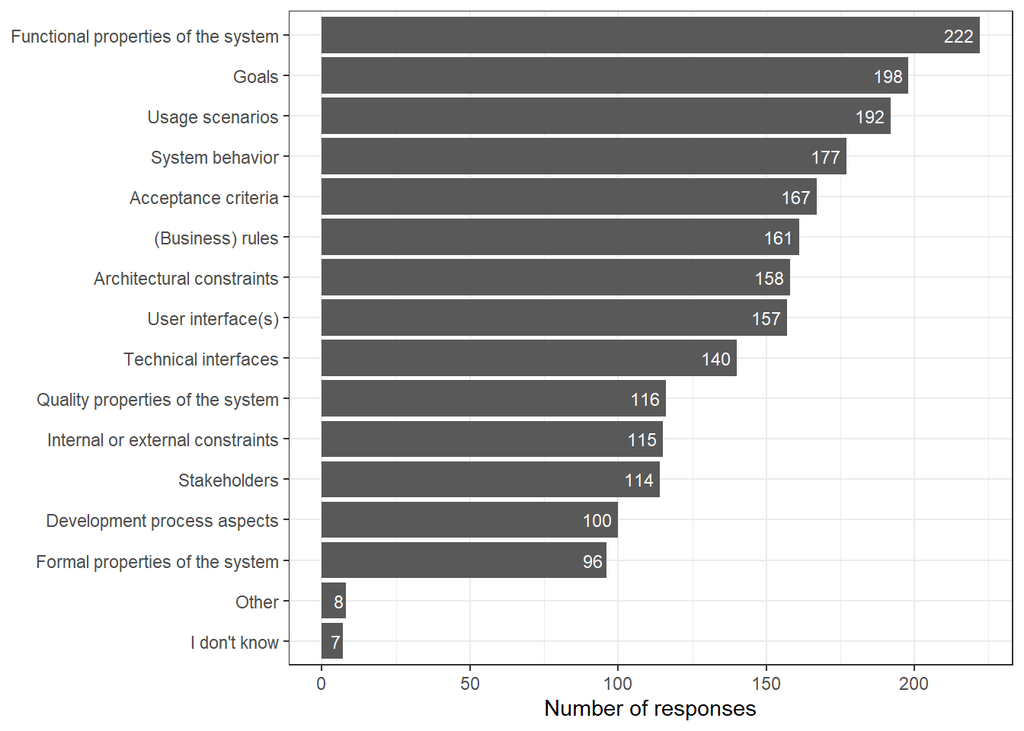

```r
d %>%
  select(v_76, v_73, v_79, v_68, v_70, v_71, v_74, v_78, v_77, v_75, v_69, v_72,
         v_466, v_557, v_576, v_80) %>%
  drop_na() %>%
  pivot_longer(cols = everything(),
               names_to = "Option", values_to = "Response") %>%
  mutate(Option = factor(Option, levels = c("v_76", "v_73", "v_79", "v_68",
                                            "v_70", "v_71", "v_74", "v_78",
                                            "v_77", "v_75", "v_69", "v_72",
                                            "v_466", "v_557", "v_576", "v_80"),
                           labels = c(
                             "Architectural constraints", "Development process aspects",
                             "Formal properties of the system",
                             "Functional properties of the system",
                             "Goals", "Quality properties of the system",
                             "(Business) rules", "Stakeholders", "System behavior",
                             "Technical interfaces", "Usage scenarios",
                             "User interface(s)", "Internal or external constraints",
                             "Acceptance criteria", "I don't know", "Other"
                           ))) %>%
  filter(Response == TRUE) %>%
  mutate(Option = fct_rev(fct_infreq(Option))) %>%
  ggplot(aes(y = Option)) +
    geom_bar(position = "stack", stat = "count") +
    geom_text(aes(label = after_stat(count)), position = "stack", stat = "count",
              hjust = 1.2, colour = "white", size = 3) +
    labs(x = "Number of responses", y = "Options") +
    theme_bw() +
    theme(legend.position = "bottom") +
    theme(axis.title.y = element_blank())
```

```r
    #ggtitle(paste0("Information to Document (n=", nrow(drop_na(select(d, v_76))), ")"))

ggsave("../figures/descriptive/document-information.pdf", device = "pdf",
       width = 10, height = 9, unit = "cm")
```

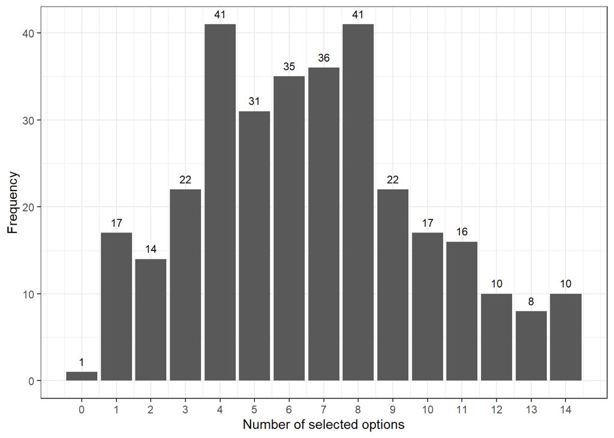

```
##        [,1]
## median "6"
## mode   "4, 8"
## iqr    "5"
## q1     "4"
## q3     "9"
## mad    "2"
## mean   "6.629283"
## sd     "3.265772"
```

```r
get_resp_distribution(c("v_76", "v_73", "v_79", "v_68", "v_70", "v_71", "v_74",
                        "v_78", "v_77", "v_75", "v_69", "v_72", "v_466", "v_557",
                        "v_576", "v_80"))
```

Answers to the question “How do you document requirements?”

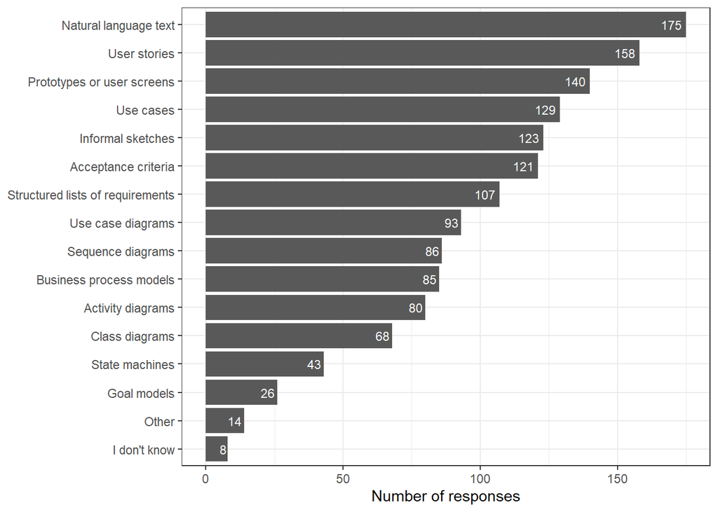

```r
d %>%
  select(v_87, v_92, v_88, v_91, v_83, v_93, v_89, v_90, v_84, v_86, v_82, v_85,
         v_463, v_558, v_575, v_95) %>%
  drop_na() %>%
  pivot_longer(cols = everything(),
               names_to = "Option", values_to = "Response") %>%
  mutate(Option = factor(Option, levels = c("v_87", "v_92", "v_88", "v_91",
                                            "v_83", "v_93", "v_89", "v_90",
                                            "v_84", "v_86", "v_82", "v_85",
                                            "v_463", "v_558", "v_575", "v_95"),
                           labels = c(
                             "Activity diagrams", "Business process models",
                             "Class diagrams", "Goal models",
                             "Natural language text",
                             #"Natural language or informal (plain) text",
                             "Prototypes or user screens", "Sequence diagrams",
                             "State machines", "Structured lists of requirements",
                             "Use case diagrams", "Use cases", "User stories",
                             "Acceptance criteria", "Informal sketches",
                             "I don't know", "Other"
                           ))) %>%
  filter(Response == TRUE) %>%
  mutate(Option = fct_rev(fct_infreq(Option))) %>%
  ggplot(aes(y = Option)) +
    geom_bar(position = "stack", stat = "count") +
    geom_text(aes(label = after_stat(count)), position = "stack", stat = "count",
              hjust = 1.2, colour = "white", size = 3) +
    labs(x = "Number of responses") +
    theme_bw() +
    theme(axis.title.y = element_blank()) #+
```

```r
    #ggtitle(paste0("Types of Documentation (n=", nrow(drop_na(select(d, v_87))), ")"))

ggsave("../figures/descriptive/document-types.pdf", device = "pdf",
       width = 10, height = 9, unit = "cm")
```

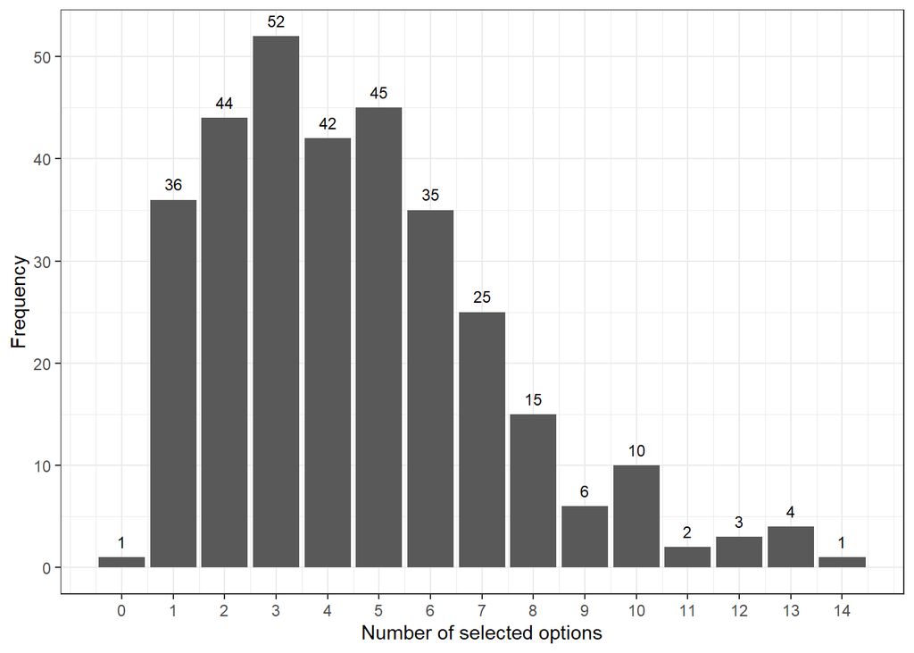

```
##        [,1]
## median "4"
## mode   "3"
## iqr    "4"
## q1     "2"
## q3     "6"
## mad    "2"
## mean   "4.535826"
## sd     "2.709842"
```

```r
get_resp_distribution(c("v_87", "v_92", "v_88", "v_91", "v_83", "v_93", "v_89",
                        "v_90", "v_84", "v_86", "v_82", "v_85", "v_463", "v_558",
                        "v_575", "v_95"))
```

Answers to the question “Have you ever failed to document one or more requirements?”

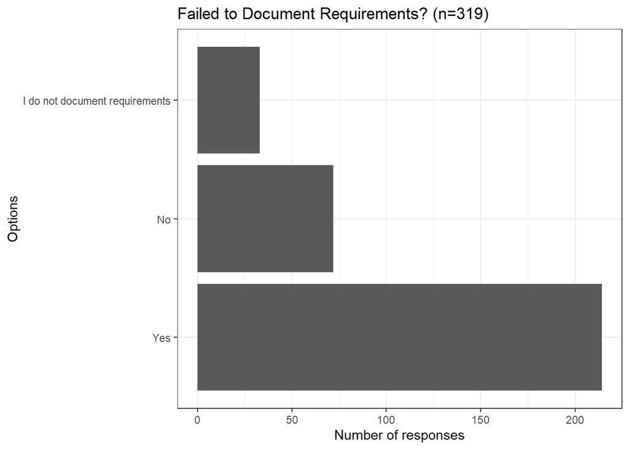

```r
d %>%
  select(v_577) %>%
  drop_na() %>%
  ggplot(aes(y = v_577)) +
    geom_bar() +
    theme_bw() +
    labs(x = "Number of responses", y = "Options") +
    ggtitle(paste0("Failed to Document Requirements? (n=", nrow(drop_na(select(d, v_577))), ")"))
```

Answers to the question “Check as many reasons for failing to document requirements that have applied in at least one circumstance.”

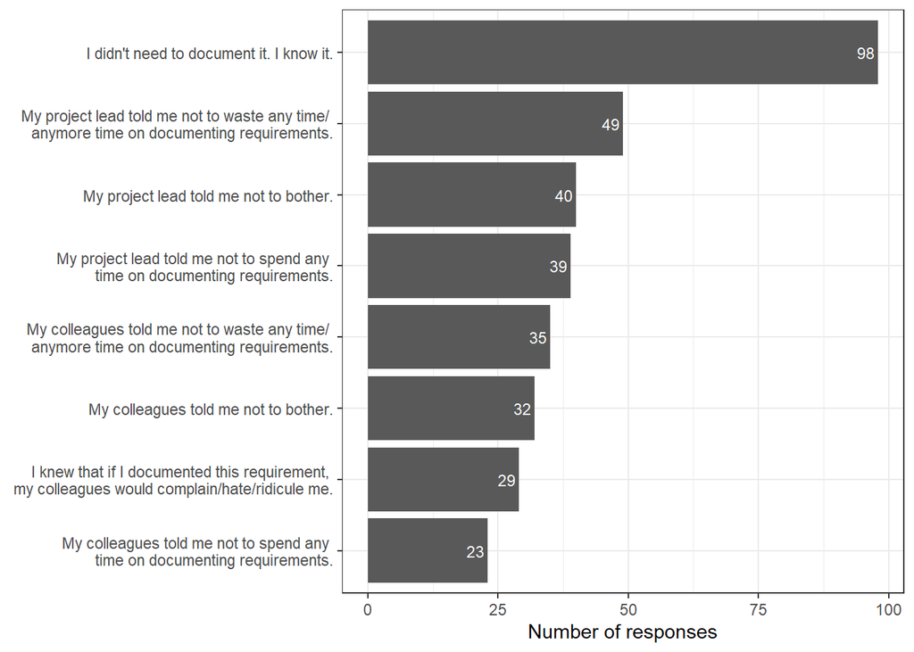

```r
d %>%
  select(v_670, v_671, v_672, v_673, v_674, v_675, v_676, v_677) %>%
  drop_na() %>%
  pivot_longer(cols = everything(),
               names_to = "Option", values_to = "Response") %>%
  mutate(Option = factor(Option, levels = c("v_670", "v_671", "v_672", "v_673",
                                            "v_674", "v_675", "v_676", "v_677"),
                           labels = c(
                             "I didn't need to document it. I know it.",
                             "I knew that if I documented this requirement, \n my colleagues would complain/hate/ridicule me.",
                             "My project lead told me not to bother.",
                             "My project lead told me not to spend any \n time on documenting requirements.",
                             "My project lead told me not to waste any time/ \n anymore time on documenting requirements.",
                             "My colleagues told me not to bother.",
                             "My colleagues told me not to spend any \n time on documenting requirements.",
                             "My colleagues told me not to waste any time/ \n anymore time on documenting requirements."
                           ))) %>%
  filter(Response == TRUE) %>%
  mutate(Option = fct_rev(fct_infreq(Option))) %>%
  ggplot(aes(y = Option)) +
    geom_bar(position = "stack", stat = "count") +
    geom_text(aes(label = after_stat(count)), position = "stack", stat = "count",
              hjust = 1.2, colour = "white", size = 3) +
    labs(x = "Number of responses") +
    theme_bw() +
    theme(axis.title.y = element_blank()) #+
```

```r
    #ggtitle(paste0("Reasons for Failing to Document (n=", nrow(drop_na(select(d, v_670))), ")"))

ggsave("../figures/descriptive/failure-reasons.pdf", device = "pdf",
       width = 14, height = 7, unit = "cm")
```

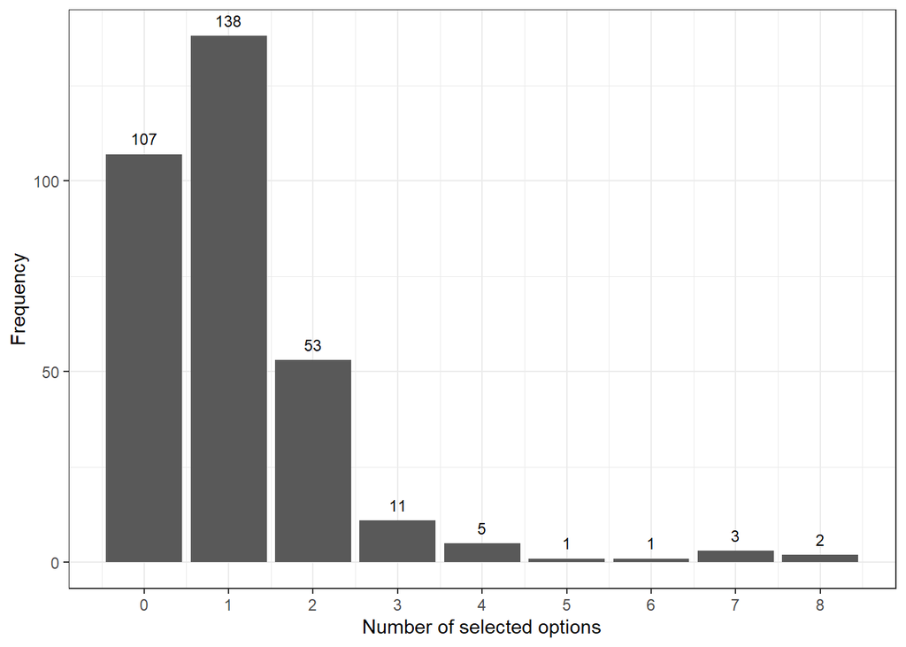

```
##        [,1]
## median "1"
## mode   "1"
## iqr    "1"
## q1     "0"
## q3     "1"
## mad    "1"
## mean   "1.074766"
## sd     "1.242736"
```

```r
get_resp_distribution(c("v_670", "v_671", "v_672", "v_673", "v_674", "v_675", "v_676", "v_677"))
```

### Non-functional Requirements

Answers to the question “Which classes of non-functional requirements do you explicitly consider in your requirements documentation?”

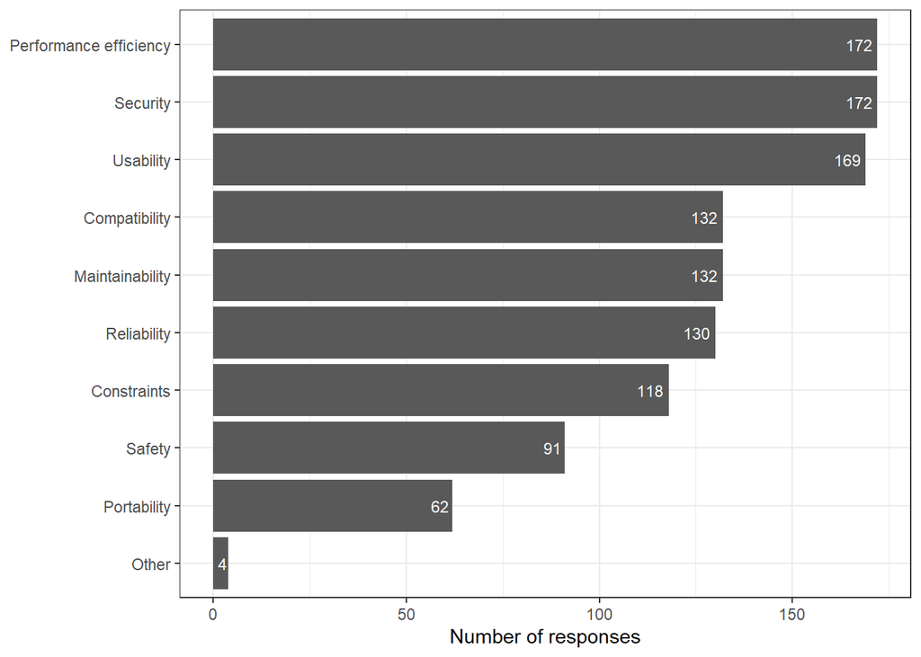

```r
d %>%
  select(v_97, v_98, v_99, v_100, v_101, v_102, v_303, v_103, v_422, v_104) %>%
  drop_na() %>%
  pivot_longer(cols = everything(),
               names_to = "NFR", values_to = "Response") %>%
  mutate(NFR = factor(NFR, levels = c("v_97", "v_98", "v_99", "v_100",
                                            "v_101", "v_102", "v_303", "v_103",
                                            "v_422", "v_104"),
                           labels = c("Compatibility", "Maintainability",
                                      "Performance efficiency", "Portability",
                                      "Reliability", "Safety", "Security",
                                      "Usability", "Constraints", "Other"
                           ))) %>%
  filter(Response == TRUE) %>%
  mutate(NFR = fct_rev(fct_infreq(NFR))) %>%
  ggplot(aes(y = NFR)) +
    geom_bar(position = "stack", stat = "count") +
    geom_text(aes(label = after_stat(count)), position = "stack", stat = "count",
              hjust = 1.2, colour = "white", size = 3) +
    labs(x = "Number of responses") +
    theme_bw() +
    theme(axis.title.y = element_blank()) #+
```

```r
    #ggtitle(paste0("Documented Classes of Non-Functional Requirements (n=", nrow(drop_na(select(d, v_97))), ")"))

ggsave("../figures/descriptive/nfrs.pdf", device = "pdf",
       width = 14, height = 7, unit = "cm")
```

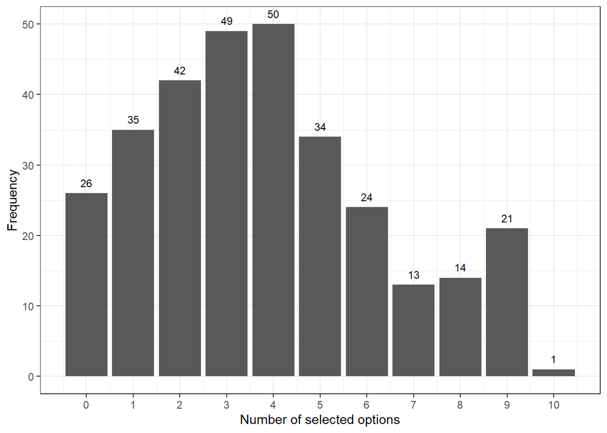

```
##        [,1]
## median "4"
## mode   "4"
## iqr    "3"
## q1     "2"
## q3     "5"
## mad    "2"
## mean   "3.825243"
## sd     "2.529413"
```

```r
get_resp_distribution(c("v_97", "v_98", "v_99", "v_100", "v_101", "v_102",
                        "v_303", "v_103", "v_422", "v_104"))
```

### Stopping Requirements Analysis

Answers to the question “Stated below are possible reasons for stopping the requirements analysis process and producing a requirements specification, capturing only what is known at the moment. Indicate your level of agreement or disagreement with the applicability of the reasons to your project.”

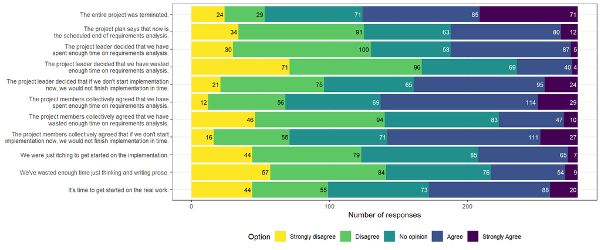

```r
d %>%
  select(v_559, v_560, v_561, v_562, v_563, v_564, v_565, v_566, v_567, v_568, v_569) %>%
  drop_na() %>%
  pivot_longer(cols = everything(),
               names_to = "question", values_to = "answer") %>%
  mutate(
    question = factor(question, levels = c("v_559", "v_560", "v_561", "v_562",
                                                "v_563", "v_564", "v_565", "v_566",
                                                "v_567", "v_568", "v_569"),
                           labels = c(
                             "The entire project was terminated.",
                             "The project plan says that now is\n the scheduled end of requirements analysis.",
                             "The project leader decided that we have\n spent enough time on requirements analysis.",
                             "The project leader decided that we have wasted\n enough time on requirements analysis.",
                             "The project leader decided that if we don't start implementation\n now, we would not finish implementation in time.",
                             "The project members collectively agreed that we have\n spent enough time on requirements analysis.",
                             "The project members collectively agreed that we have\n wasted enough time on requirements analysis.",
                             "The project members collectively agreed that if we don't start\n implementation now, we would not finish implementation in time.",
                             "We were just itching to get started on the implementation.",
                             "We've wasted enough time just thinking and writing prose.",
                             "It's time to get started on the real work."
                           )),
    answer = fct_rev(answer),
    textcolor = if_else(as.integer(answer) <= 3, "white", "black")
    ) %>%
  ggplot(aes(y = question, fill = answer)) +
    geom_bar(position = "stack", stat = "count") +
    geom_text(aes(label = after_stat(count), color = textcolor, group = answer),
              position = "stack", stat = "count",
              hjust = 1.2, size = 3) +
    labs(x = "Number of responses", fill = "Option") +
    scale_fill_viridis_d() +
    scale_color_identity() +
    theme_bw() +
    theme(legend.position = "bottom", axis.title.y = element_blank()) +
    guides(fill = guide_legend(reverse = TRUE)) +
    scale_y_discrete(limits = rev)
```

```r
    #ggtitle(paste0("Reasons for Stopping the Requirements Analysis Process (n=", nrow(drop_na(select(d, v_559))), ")"))

ggsave("../figures/descriptive/stopping.pdf", device = "pdf",
       width = 24, height = 14, unit = "cm")
```

### Requirements Validation

Answers to the question “How do you align software testing with requirements?”

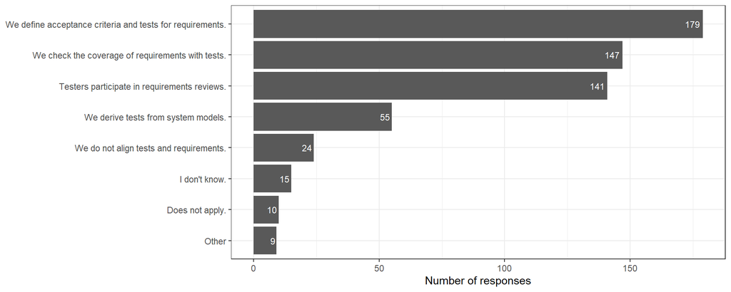

```r
d %>%
  select(v_158, v_159, v_160, v_161, v_162, v_573, v_574, v_163) %>%
  drop_na() %>%
  pivot_longer(cols = everything(),
               names_to = "NFR", values_to = "Response") %>%
  mutate(NFR = factor(NFR, levels = c("v_158", "v_159", "v_160", "v_161", "v_162",
                                      "v_573", "v_574", "v_163"),
                           labels = c("Testers participate in requirements reviews.",
                                      "We check the coverage of requirements with tests.",
                                      "We define acceptance criteria and tests for requirements.",
                                      "We derive tests from system models.",
                                      "We do not align tests and requirements.",
                                      "I don't know.", "Does not apply.", "Other"
                           ))) %>%
  filter(Response == TRUE) %>%
  mutate(NFR = fct_rev(fct_infreq(NFR))) %>%
  ggplot(aes(y = NFR)) +
    geom_bar(position = "stack", stat = "count") +
    geom_text(aes(label = after_stat(count)), position = "stack", stat = "count",
              hjust = 1.2, colour = "white", size = 3) +
    labs(x = "Number of responses") +
    theme_bw() +
    theme(axis.title.y = element_blank())# +
```

```r
    #ggtitle(paste0("Alignment of Software Testing with Requirements (n=", nrow(drop_na(select(d, v_158))), ")"))


ggsave("../figures/descriptive/testing.pdf", device = "pdf",
       width = 14, height = 5, unit = "cm")
```

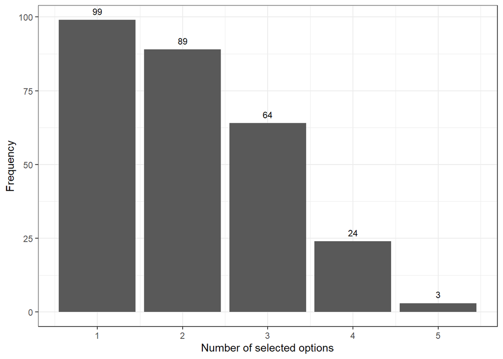

```
##        [,1]
## median "2"
## mode   "1"
## iqr    "2"
## q1     "1"
## q3     "3"
## mad    "1"
## mean   "2.078853"
## sd     "1.011206"
```

```r
get_resp_distribution(c("v_158", "v_159", "v_160", "v_161", "v_162", "v_573",
                        "v_574", "v_163"))
```

### Problems

Answers to the question “How much do you agree or disagree with the following statements about your project?”

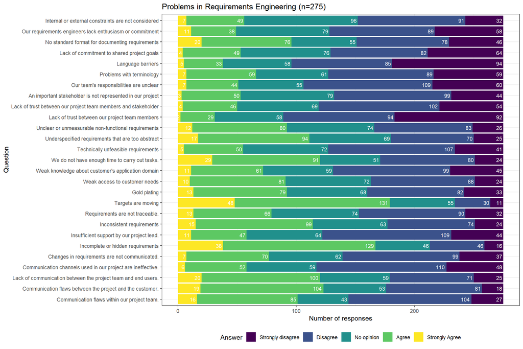

```r
d %>%
  select(v_385, v_386, v_418, v_409, v_410, v_388, v_389, v_392, v_393, v_394,
         v_395, v_396, v_397, v_399, v_401, v_402, v_403, v_404, v_411, v_405,
         v_408, v_407, v_406, v_387, v_417, v_459, v_571) %>%
  drop_na() %>%
  pivot_longer(cols = everything(),
               names_to = "question", values_to = "answer") %>%
  mutate(question = factor(question,
                           levels = c("v_385", "v_386", "v_418", "v_409", "v_410",
                                      "v_388", "v_389", "v_392", "v_393", "v_394",
                                      "v_395", "v_396", "v_397", "v_399", "v_401",
                                      "v_402", "v_403", "v_404", "v_411", "v_405",
                                      "v_408", "v_407", "v_406", "v_387", "v_417",
                                      "v_459", "v_571"),
                           labels = c(
                             "Communication flaws within our project team.",
                             "Communication flaws between the project and the customer.",
                             "Lack of communication between the project team and end users.",
                             "Communication channels used in our project are ineffective.",
                             "Changes in requirements are not communicated.",
                             "Incomplete or hidden requirements",
                             "Insufficient support by our project lead.",
                             "Inconsistent requirements",
                             "Requirements are not traceable.",
                             "Targets are moving",
                             "Gold plating",
                             "Weak access to customer needs",
                             "Weak knowledge about customer's application domain",
                             "We do not have enough time to carry out tasks.",
                             "Technically unfeasible requirements",
                             "Underspecified requirements that are too abstract",
                             "Unclear or unmeasurable non-functional requirements",
                             "Lack of trust between our project team members",
                             "Lack of trust between our project team members and stakeholder",
                             "An important stakeholder is not represented in our project",
                             "Our team's responsibilities are unclear",
                             "Problems with terminology",
                             "Language barriers",
                             "Lack of commitment to shared project goals",
                             "No standard format for documenting requirements",
                             "Our requirements engineers lack enthusiasm or commitment",
                             "Internal or external constraints are not considered"
                           ))) %>%
  ggplot(aes(y = question, fill = answer)) +
    geom_bar(position = "stack", stat = "count") +
    geom_text(aes(label = after_stat(count)), position = "stack", stat = "count",
              hjust = 1.2, colour = "white", size = 3) +
    labs(x = "Number of responses", y = "Question", fill = "Answer") +
    theme_bw() +
    theme(legend.position = "bottom") +
    ggtitle(paste0("Problems in Requirements Engineering (n=", nrow(drop_na(select(d, v_385))), ")"))
```

### Top Problems

Answers to the question “Considering your personally experienced problems stated in the previous question, which ones would you classify as the five most critical ones?”

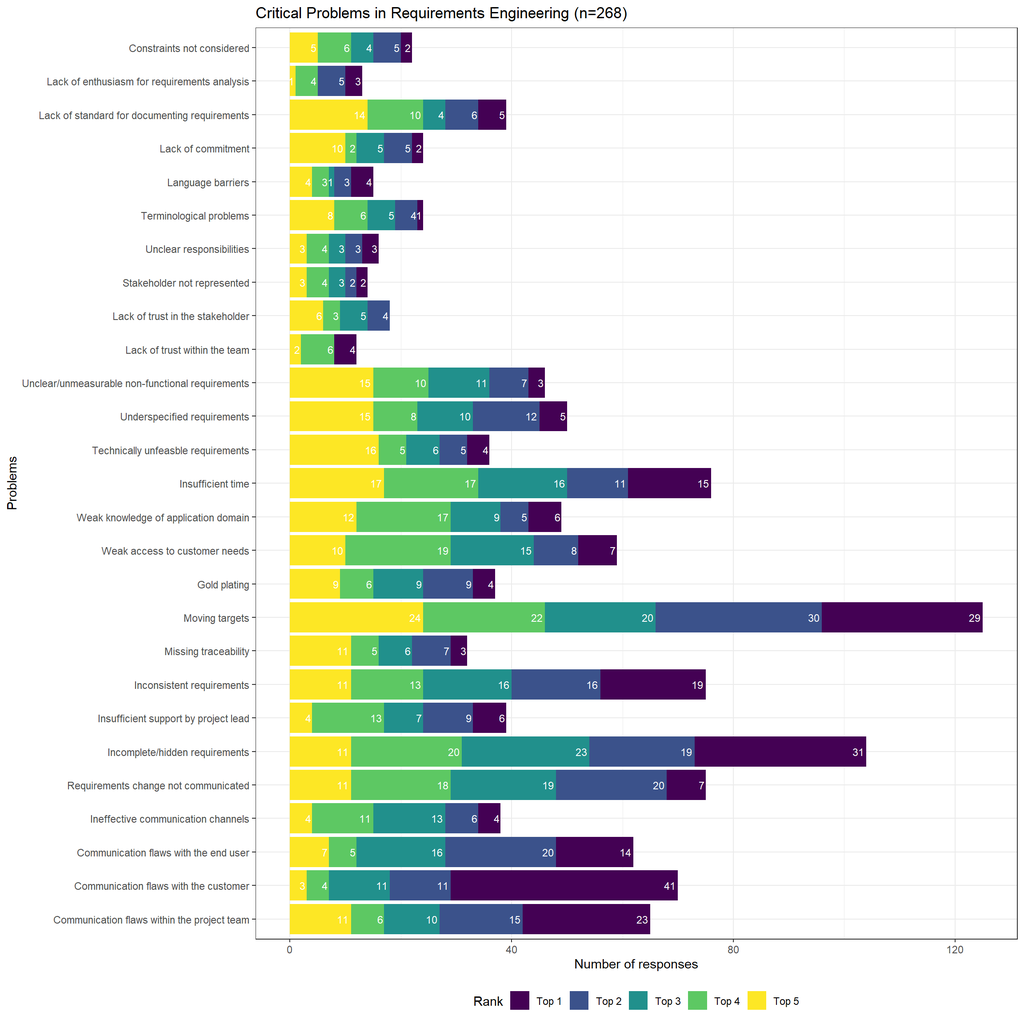

```r
d %>%
  select(v_661, v_662, v_663, v_664, v_665) %>%
  drop_na() %>%
  pivot_longer(cols = everything(), names_to = "Rank", values_to = "Response") %>%
  mutate(Rank = factor(Rank, levels = c("v_661", "v_662", "v_663", "v_664", "v_665"),
                       labels = c("Top 1", "Top 2", "Top 3", "Top 4", "Top 5"),
                       ordered = TRUE)) %>%
  filter(Response != "-") %>%
  ggplot(aes(y = Response, fill = Rank)) +
    geom_bar(position = "stack", stat = "count") +
    geom_text(aes(label = after_stat(count)), position = "stack", stat = "count",
              hjust = 1.2, colour = "white", size = 3) +
    labs(x = "Number of responses", y = "Problems", fill = "Rank") +
    #scale_fill_ordinal(limits = rev) +
    theme_bw() +
    theme(legend.position = "bottom") +
    ggtitle(paste0("Critical Problems in Requirements Engineering (n=", nrow(drop_na(select(d, v_661))), ")"))
```

[^1] Wagner, S., Fernández, D. M., Felderer, M., Vetrò, A., Kalinowski, M., Wieringa, R., … & Winkler, D. (2019). Status quo in requirements engineering: A theory and a global family of surveys. *ACM Transactions on Software Engineering and Methodology (TOSEM)*, *28*(2), 1-48.